# Phylogenetic Analysis of Salamander Genome Size

Clay Cressler

06/09/2020

This is an updated version of the analyses that were initially carried out several years ago. We had wanted to use $\texttt{Ouwie}$ to do these analyses but previously, there were undiagnosed issues with its fitting algorithm. As such, we ended up using $\texttt{ouch}$ for all analyses, which prevented us from ever testing models with multiple $\alpha$ or $\sigma^2$ parameters. However, I spent time working through these issues in Spring 2020 and am now satisfied that $\texttt{ouch}$ and $\texttt{OUwie}$ produce identical results, at least once you specify a value for ‘shift.point’ to make the way that $\texttt{OUwie}$ handles regimes identical to $\texttt{ouch}$.

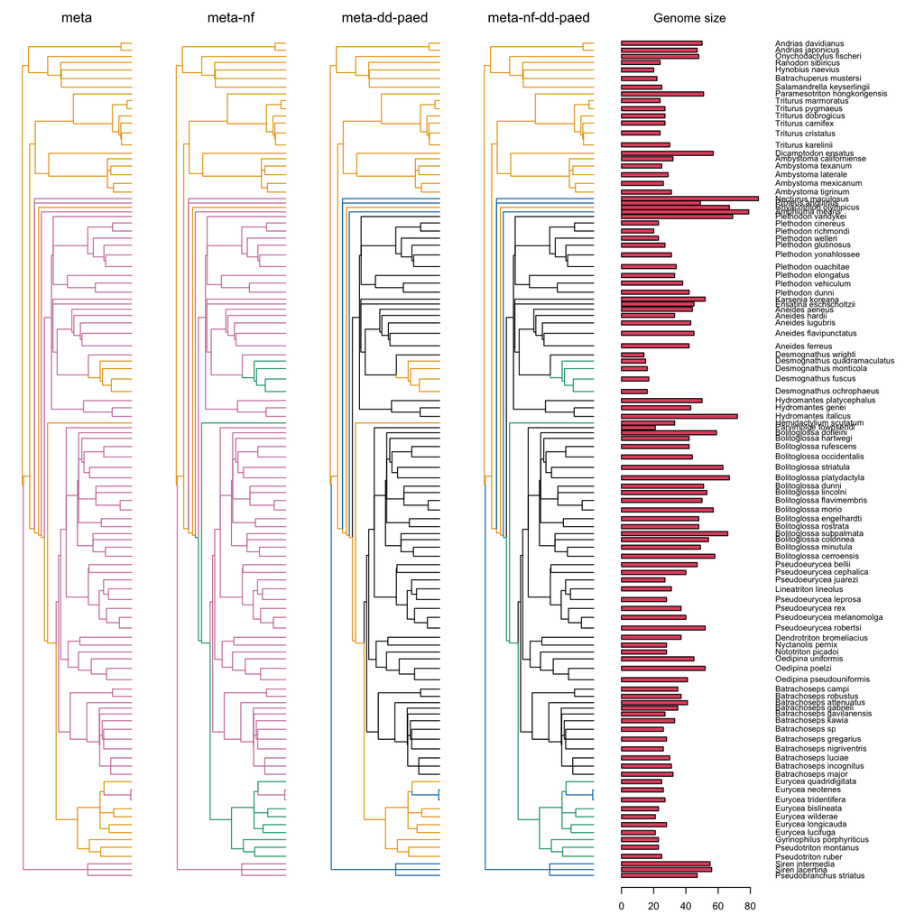

Figure 1: The four evolutionary hypotheses, specified as regime paintings. Black = Direct development, Orange = Metamorphosis, Blue green = Non-feeding metamorphosis, Blue = Paedomorphosis, Reddish purple = Direct development or paedomorphosis.

Here are the four different adaptive hypothesis regime paintings (Fig. 2).

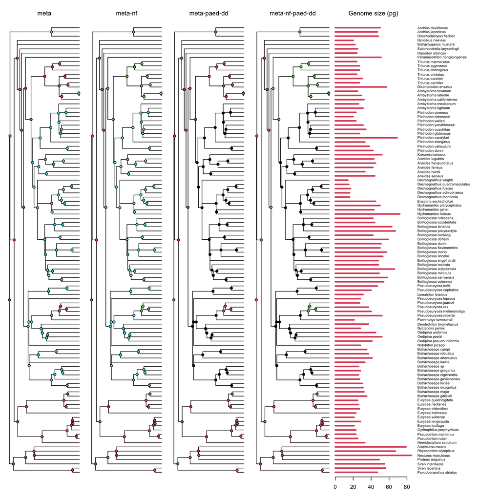

Figure 2: The four evolutionary hypotheses, specified as regime paintings. Black = Direct development, Red = Metamorphosis, Green = Plethodontid metamorphosis, Blue = Paedomorphosis, Cyan = Direct development or paedomorphosis.

I will proceed with fitting the following models: a standard Brownian motion model (BM1), a Brownian motion model where the drift parameter ($\sigma$) varies across regimes (BMS), an Ornstein-Uhlenbeck (OU) model where only $\theta$ varies across regimes (OUM), an OU model where selection strength varies across regimes ($\alpha$) (OUMA), an OU model where drift varies across regimes (OUMV), and an OU model where both selection and drift vary across regimes (OUMVA).

The best-fitting model is the OU model with 4 selective regimes (1=direct development, 2=metamorphosis, 3=metamorphosing plethodontids, 4=paedomorphosis), with separate drift parameters for each regime, although the model with a single drift parameter has very similar AICc score. Here are the AICc values and parameter estimates for each of the models.

```
##               Hypothesis   loglik  AICc    alpha                      sigma
## 1   meta.nf.dd.paed.OUMV   7.4400  5.00 1.05e-07 0.365, 0.355, 0.187, 0.249
## 2    meta.nf.dd.paed.OUM   3.3900  6.07 1.01e-07                      0.338
## 3           meta.nf.OUMV   4.3700  6.40 9.02e-08        0.357, 0.187, 0.364
## 4       meta.dd.paed.OUM   1.1000  8.40 5.56e-08                      0.346
## 5            meta.nf.OUM   1.0200  8.55 7.65e-08                      0.346
## 6               meta.OUM  -0.3480  9.09 4.58e-08                      0.351
## 7              meta.OUMV  -0.0766 10.80 3.58e-08               0.324, 0.363
## 8      meta.dd.paed.OUMV   2.0800 11.00 5.60e-08        0.367, 0.323, 0.251
## 9          meta.nf.OUMVA   4.3700 11.10 7.98e-08        0.357, 0.187, 0.364
## 10             meta.OUMA  -0.3480 11.30 4.75e-08                      0.351
## 11 meta.nf.dd.paed.OUMVA   7.4400 12.50 1.01e-07 0.365, 0.355, 0.187, 0.249
## 12     meta.dd.paed.OUMA   1.1000 12.90 5.56e-08                      0.346
## 13            meta.OUMVA  -0.0766 13.00 4.75e-08               0.324, 0.363
## 14          meta.nf.OUMA   1.0200 13.10 7.98e-08                      0.346
```

[output cut: 29 more lines]

To help interpret the biological implications of the parameter values of the best-fitting model, it is useful to calculate the values of the deterministic and stochastic terms of the OU model ($\alpha (\theta-X)$ and $\sigma$). I will assume that $X$ is the average genome size for salamanders in each of the selective regimes. Plugging those genome size values, along with the corresponding parameter estimates for each regime gives a sense of how strong selection and drift are in each regime. Based on this data, you can say genome size evolution for direct developers and feeding metamorphosers is primarily driven by drift, with no strong deterministic trend in genome size. However, there is a strong deterministic trend towards small genomes in metamorphosing plethodontids, and towards large genomes in paedomorphs.

```
## # A tibble: 4 x 6
##   regime  meanGenomeSize     alpha     theta `deterministic tr… `drift intensit…
##   <chr>            <dbl>     <dbl>     <dbl>              <dbl>            <dbl>
## 1 DD                3.66   1.05e-7   -3.77e5      -0.0396                  0.365
## 2 Meta-F            3.46   1.05e-7    3.62e0       0.0000000168            0.355
## 3 Meta-NF           3.07   1.05e-7   -5.55e6      -0.583                   0.187
## 4 Paed              3.89   1.05e-7    4.41e6       0.463                   0.249
```

However, it is important to assess how strong the support for this hypothesis truly is. Following the protocol of Boettiger et al. (2012) for phylogenetic Monte Carlo, I need to simulate datasets under different models and ask how often the true (data-generating) model is rejected in favor of an alternative model.

We will do the following pairwise comparisons of models:

1. $metamorphosis-other$ (OUM) versus $BM$: this tests whether we can confidently reject a non-adaptive hypothesis.
2. $meta-paed-dd$ (OUM) versus $metamorphosis-other$ (OUM): this tests whether distinguishing between non-metamorphosing strategies is supported.
3. $meta_f-meta_{nf}-other$ (OUMV) versus $metamorphosis-other$ (OUM): this tests whether distinguishing between different metamorphosis strategies is supported.
4. $meta_f-meta_{nf}-paed-dd$ (OUMV) versus $meta-paed-dd$ (OUM): this tests whether a separate regime for metamorphosing plethodontids is supported.
5. $meta_f-meta_{nf}-paed-dd$ (OUMV) versus $meta_f-meta_{nf}-other$ (OUMV): this tests whether a separate regime for direct developers is supported.
6. $meta_f-meta_{nf}-paed-dd$ (OUMV) versus $meta_f-meta_{nf}-paed-dd$ (OUM): this tests whether multiple $\sigma$ values is supported.

We will simulate datasets under all of the models above, and then fit data generated by each of the two models under comparison to each of those models.

We can also use these fits to look at the confidence intervals for each of the parameters of the best-fitting model using a parametric bootstrap.

```r
PMCfits <- readRDS("PMCfits.RDS")

## Bootstrap parameter estimates
data.frame(parameter=c('alpha','sigma.sq (DD)', 'sigma.sq (M)', 'sigma.sq (Mpleth)', 'sigma.sq (P)', 'theta (DD)', 'theta (M)', 'theta (Mpleth)', 'theta (P)'),
           CI=c((lapply(PMCfits, function(f) f[["fit.oumv.meta.nf.dd.paed.to.oumv.meta.nf.dd.paed.data"]]$solution['alpha',] %>% unique) %>% unlist %>% sort)[c(12,488)] %>% signif(3) %>% paste(., collapse=", "),
                (lapply(PMCfits, function(f) f[["fit.oumv.meta.nf.dd.paed.to.oumv.meta.nf.dd.paed.data"]]$solution['sigma.sq',1]) %>% unlist %>% sort)[c(12,488)] %>% sqrt %>% signif(3) %>% paste(., collapse=", "),
                (lapply(PMCfits, function(f) f[["fit.oumv.meta.nf.dd.paed.to.oumv.meta.nf.dd.paed.data"]]$solution['sigma.sq',2]) %>% unlist %>% sort)[c(12,488)] %>% sqrt %>% signif(3) %>% paste(., collapse=", "),
                (lapply(PMCfits, function(f) f[["fit.oumv.meta.nf.dd.paed.to.oumv.meta.nf.dd.paed.data"]]$solution['sigma.sq',3]) %>% unlist %>% sort)[c(12,488)] %>% sqrt %>% signif(3) %>% paste(., collapse=", "),
                (lapply(PMCfits, function(f) f[["fit.oumv.meta.nf.dd.paed.to.oumv.meta.nf.dd.paed.data"]]$solution['sigma.sq',4]) %>% unlist %>% sort)[c(12,488)] %>% sqrt %>% signif(3) %>% paste(., collapse=", "),
                (lapply(PMCfits, function(f) f[["fit.oumv.meta.nf.dd.paed.to.oumv.meta.nf.dd.paed.data"]]$theta[1,1]) %>% unlist %>% sort)[c(12,488)] %>% signif(3) %>% paste(., collapse=","),
                (lapply(PMCfits, function(f) f[["fit.oumv.meta.nf.dd.paed.to.oumv.meta.nf.dd.paed.data"]]$theta[2,1]) %>% unlist %>% sort)[c(12,488)] %>% signif(3) %>% paste(., collapse=","),
                (lapply(PMCfits, function(f) f[["fit.oumv.meta.nf.dd.paed.to.oumv.meta.nf.dd.paed.data"]]$theta[3,1]) %>% unlist %>% sort)[c(12,488)] %>% signif(3) %>% paste(., collapse=","),
                (lapply(PMCfits, function(f) f[["fit.oumv.meta.nf.dd.paed.to.oumv.meta.nf.dd.paed.data"]]$theta[4,1]) %>% unlist %>% sort)[c(12,488)] %>% signif(3) %>% paste(., collapse=","))
)
```

```
##           parameter               CI
## 1             alpha    1.01e-07, 1.7
## 2     sigma.sq (DD)     0.308, 0.545
## 3      sigma.sq (M)     0.252, 0.525
## 4 sigma.sq (Mpleth)     0.108, 0.283
## 5      sigma.sq (P)     0.112, 0.464
## 6        theta (DD) -2670000,1990000
## 7         theta (M)         3.32,3.9
## 8    theta (Mpleth)    -7620000,3.28
## 9         theta (P)     3.96,6290000
```

To determine whether the data really supports the conclusions we want to draw from the AICc table, we use the phylogenetic Monte Carlo approach of Boettiger et al. 2012. We define the difference in the log-likelihoods between the two models as our test statistic: $\delta = -2 (\log L_0 - \log L_1)$, where we assume that the $L_1$ is the likelihood of the more complex model. Higher values of this likelihood ratio indicate more support for the complex model. We will use the simulated datasets to estimate the distribution of $\delta$ when the data is generated by either of the two models under comparison. Our first comparison is between the meta hypothesis, fitted with the OU model (the simplest adaptive hypothesis), and the non-adaptive Brownian motion hypothesis. The p-value for this comparison is 0.016: when the data is generated by a non-adaptive model, the value of the test statistic is almost never as large as the value that we observed with the true dataset.

```r
## The true value of the test statistic
delta <- -2*(results[["BM1"]]$loglik - results[["meta.OUM"]]$loglik)

## The distribution of the test statistic when the data is generated by the BM1 model
delta.dist <- -2*((lapply(PMCfits, function(f) f[["fit.bm1.to.bm1.data"]]$loglik) %>% unlist) -
                    (lapply(PMCfits, function(f) f[["fit.oum.meta.to.bm1.data"]]$loglik) %>% unlist))

## the proportion of the simulated values larger than the test statistic provides an approximation to the p-value for the test, the probability that a difference at least as large would be seen under model 0 (BM)

meta.v.BM.p <- sum(delta < delta.dist)/length(delta.dist)
meta.v.BM.p
```

```
## [1] 0.016
```

We can also look at the overlap between the distributions of the test statistic when the data is generated by the non-adaptive model versus the adaptive model to get a sense of power. You can see that the power is fairly high (0.69), meaning that 69% of the test statistic values when the data is generated by the adaptive model are larger than the 95th percentile of the distribution when the data is generated by the non-adaptive model. Both the p-value and the power can be visualized by a plot of the two distributions (Fig. 3A).)

```r
## The distribution of the test statistic when the data is generated by the oumv.meta.nf.dd.paed model
delta.dist.2 <- -2*((lapply(PMCfits, function(f) f[["fit.bm1.to.oum.meta.data"]]$loglik) %>% unlist) -
                    (lapply(PMCfits, function(f) f[["fit.oum.meta.to.oum.meta.data"]]$loglik) %>% unlist))
## The degree of overlap between this distribution and the one above gives a sense of the power.
## The amount of this distribution to the right of the test statistic value that would reject the non-adaptive model with a false positive rate of 5% above gives the probability of rejecting model 0 when the data are produced by model 1 (e.g., the power)
meta.v.bm.power <- sum(delta.dist.2 > sort(delta.dist)[475])/length(delta.dist.2)
meta.v.bm.power
```

```
## [1] 0.69
```

Using the same methodology, we can calculate the approximate p-value and power for the second test, between $meta-paed-dd$ (OUM) and $metamorphosis-other$ (OUM). This tests whether more finely subdividing non-metamorphosing strategies into direct development and paedomorphosis provides a better fit to the data than simply between distinguishing between metamorphosing and non-metamorphosing strategies. Here the p-value is 0.096 and the power is 0.39, suggesting that the addition of direct development and paedomorphosis as separate constraint regimes does not really improve the explanatory power of the model. See Fig. 3B for a visual depiction of these results.

```r
delta <- -2*(results[["meta.OUM"]]$loglik - results[["meta.dd.paed.OUM"]]$loglik)
delta.dist <- -2*((lapply(PMCfits, function(f) f[["fit.oum.meta.to.oum.meta.data"]]$loglik) %>% unlist) -
                    (lapply(PMCfits, function(f) f[["fit.oum.meta.dd.paed.to.oum.meta.data"]]$loglik) %>% unlist))
delta.dist.2 <- -2*((lapply(PMCfits, function(f) f[["fit.oum.meta.to.oum.meta.dd.paed.data"]]$loglik) %>% unlist) -
                    (lapply(PMCfits, function(f) f[["fit.oum.meta.dd.paed.to.oum.meta.dd.paed.data"]]$loglik) %>% unlist))
## p-value
meta.dd.paed.v.meta.p <- sum(delta < delta.dist)/length(delta.dist)
## power
meta.dd.paed.v.meta.power <- sum(delta.dist.2 > sort(delta.dist)[475])/length(delta.dist.2)
meta.dd.paed.v.meta.p
```

```
## [1] 0.096
```

```r
meta.dd.paed.v.meta.power
```

```
## [1] 0.39
```

Using the same methodology, we can calculate the approximate p-value and power for the third test, $meta_f-meta_{nf}-other$ (OUMV) and $metamorphosis-other$ (OUM). This tests whether distinguishing between different metamorphosis strategies is supported. Here the p-value is 0.032 and the power is 0.796, implying we can confidently reject the hypothesis that the simpler model produces a better fit to the data than the more complicated model that distinguishes among metamorphosing life histories. See Fig. 3C for a visual depiction of these results.

```r
delta <- -2*(results[["meta.OUM"]]$loglik - results[["meta.nf.OUMV"]]$loglik)
delta.dist <- -2*((lapply(PMCfits, function(f) f[["fit.oum.meta.to.oum.meta.data"]]$loglik) %>% unlist) -
                    (lapply(PMCfits, function(f) f[["fit.oumv.meta.nf.to.oum.meta.data"]]$loglik) %>% unlist))
delta.dist.2 <- -2*((lapply(PMCfits, function(f) f[["fit.oum.meta.to.oumv.meta.nf.data"]]$loglik) %>% unlist) -
                    (lapply(PMCfits, function(f) f[["fit.oumv.meta.nf.to.oumv.meta.nf.data"]]$loglik) %>% unlist))
## p-value
meta.nf.v.meta.p <- sum(delta < delta.dist)/length(delta.dist)
## power
meta.nf.v.meta.power <- sum(delta.dist.2 > sort(delta.dist)[475])/length(delta.dist.2)
meta.nf.v.meta.p
```

```
## [1] 0.032
```

```r
meta.nf.v.meta.power
```

```
## [1] 0.796
```

We also calculate the p-value and power for the fourth test, $meta_f-meta_{nf}-paed-dd$ (OUMV) versus $meta-paed-dd$ (OUM). This tests whether separate regimes for feeding and non-feeding metamorphosis are supported, after accounting for the two non-metamorphosing strategies. Given the results above, it is unsurprising that the more complicated model is strongly supported, with a p-value of 0.03 and power of 0.88. See Fig. 3D for a visual depiction of these results.

```r
delta <- -2*(results[["meta.dd.paed.OUM"]]$loglik - results[["meta.nf.dd.paed.OUMV"]]$loglik)
delta.dist <- -2*((lapply(PMCfits, function(f) f[["fit.oum.meta.dd.paed.to.oum.meta.dd.paed.data"]]$loglik) %>% unlist) -
                    (lapply(PMCfits, function(f) f[["fit.oumv.meta.nf.dd.paed.to.oum.meta.dd.paed.data"]]$loglik) %>% unlist))
delta.dist.2 <- -2*((lapply(PMCfits, function(f) f[["fit.oum.meta.dd.paed.to.oumv.meta.nf.dd.paed.data"]]$loglik) %>% unlist) -
                    (lapply(PMCfits, function(f) f[["fit.oumv.meta.nf.dd.paed.to.oumv.meta.nf.dd.paed.data"]]$loglik) %>% unlist))
## p-value
meta.nf.dd.paed.v.meta.dd.paed.p <- sum(delta < delta.dist)/length(delta.dist)
## power
meta.nf.dd.paed.v.meta.dd.paed.power <- sum(delta.dist.2 > sort(delta.dist)[475])/length(delta.dist.2)
meta.nf.dd.paed.v.meta.dd.paed.p
```

```
## [1] 0.03
```

```r
meta.nf.dd.paed.v.meta.dd.paed.power
```

```
## [1] 0.88
```

We also calculate the p-value and power for the fifth test, $meta_f-meta_{nf}-paed-dd$ (OUMV) versus $meta_f-meta_{nf}-other$ (OUMV). This tests whether allowing separate regimes for direct developers and paedomorphs is supported, once you have accounted for feeding and non-feeding metamorphosis. For this comparison, the p-value is 0.1 and the power is 0.54, indicating that there is some support for the more complex model, although it is not strong. See Fig. 3E for a visual depiction of these results.

```r
delta <- -2*(results[["meta.nf.OUMV"]]$loglik - results[["meta.nf.dd.paed.OUMV"]]$loglik)
delta.dist <- -2*((lapply(PMCfits, function(f) f[["fit.oumv.meta.nf.to.oumv.meta.nf.data"]]$loglik) %>% unlist) -
                    (lapply(PMCfits, function(f) f[["fit.oumv.meta.nf.dd.paed.to.oumv.meta.nf.data"]]$loglik) %>% unlist))
delta.dist.2 <- -2*((lapply(PMCfits, function(f) f[["fit.oumv.meta.nf.to.oumv.meta.nf.dd.paed.data"]]$loglik) %>% unlist) -
                    (lapply(PMCfits, function(f) f[["fit.oumv.meta.nf.dd.paed.to.oumv.meta.nf.dd.paed.data"]]$loglik) %>% unlist))
## p-value
meta.nf.dd.paed.v.meta.nf.p <- sum(delta < delta.dist)/length(delta.dist)
## power
meta.nf.dd.paed.v.meta.nf.power <- sum(delta.dist.2 > sort(delta.dist)[475])/length(delta.dist.2)
meta.nf.dd.paed.v.meta.nf.p
```

```
## [1] 0.102
```

```r
meta.nf.dd.paed.v.meta.nf.power
```

```
## [1] 0.544
```

Finally, just to cross all the t’s and dot all the i’s, we can calculate the p-value and power for the sixth test, $meta_f-meta_{nf}-paed-dd$ (OUMV) versus $meta_f-meta_{nf}-paed-dd$ (OUM), which tests whether multiple $\sigma$ values is well-supported by the data. Here the p-value is 0.088 and the power is 0.67, suggesting fairly good support for the more complex model. See Fig. 3F for a visual depiction of these results.

```r
delta <- -2*(results[["meta.nf.dd.paed.OUM"]]$loglik - results[["meta.nf.dd.paed.OUMV"]]$loglik)
delta.dist <- -2*((lapply(PMCfits, function(f) f[["fit.oum.meta.nf.dd.paed.to.oum.meta.nf.dd.paed.data"]]$loglik) %>% unlist) -
                    (lapply(PMCfits, function(f) f[["fit.oumv.meta.nf.dd.paed.to.oum.meta.nf.dd.paed.data"]]$loglik) %>% unlist))
delta.dist.2 <- -2*((lapply(PMCfits, function(f) f[["fit.oum.meta.nf.dd.paed.to.oumv.meta.nf.dd.paed.data"]]$loglik) %>% unlist) -
                    (lapply(PMCfits, function(f) f[["fit.oumv.meta.nf.dd.paed.to.oumv.meta.nf.dd.paed.data"]]$loglik) %>% unlist))
## p-value
meta.nf.dd.paed.oumv.v.meta.nf.dd.paed.oum.p <- sum(delta < delta.dist)/length(delta.dist)
## power
meta.nf.dd.paed.oumv.v.meta.nf.dd.paed.oum.power  <-sum(delta.dist.2 > sort(delta.dist)[475])/length(delta.dist.2)
meta.nf.dd.paed.oumv.v.meta.nf.dd.paed.oum.p
```

```
## [1] 0.088
```

```r
meta.nf.dd.paed.oumv.v.meta.nf.dd.paed.oum.power
```

```
## [1] 0.674
```

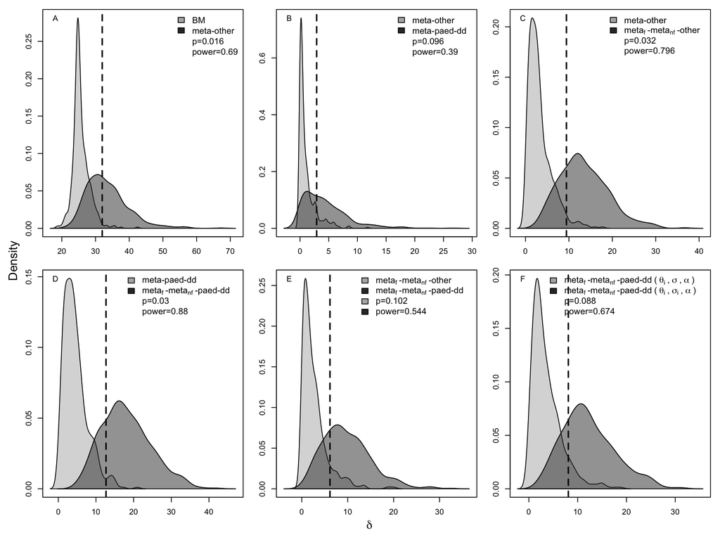

Figure 3: Comparing the distributions of the test statistic when the data is generated by simpler (light gray) or more complex (dark gray) evolutionary models. The dashed line gives the actual value of the test statistic for the true data.

## 0.1 Analyses with a different evolutionary history for plethodontids

[figure not shown]

```
##                                  Hypothesis  AICc    alpha
## meta.nf.dd.paed.OUMV   meta.nf.dd.paed.OUMV  5.21 1.13e-07
## meta.nf.dd.paed.OUM     meta.nf.dd.paed.OUM  6.11 1.01e-07
## meta.nf.OUMV                   meta.nf.OUMV  6.61 8.52e-08
## meta.dd.paed.OUM           meta.dd.paed.OUM  8.55 6.03e-08
## meta.nf.OUM                     meta.nf.OUM  9.04 7.63e-08
## meta.OUM                           meta.OUM  9.51 4.13e-08
## meta.OUMV                         meta.OUMV 11.00 3.57e-08
## meta.dd.paed.OUMV         meta.dd.paed.OUMV 11.10 6.59e-08
## meta.nf.OUMVA                 meta.nf.OUMVA 11.30 7.63e-08
## meta.OUMA                         meta.OUMA 11.70 4.13e-08
## meta.nf.dd.paed.OUMVA meta.nf.dd.paed.OUMVA 12.70 1.05e-07
## meta.dd.paed.OUMA         meta.dd.paed.OUMA 13.10 6.03e-08
## meta.nf.dd.paed.OUMA   meta.nf.dd.paed.OUMA 13.10 1.05e-07
## meta.OUMVA                       meta.OUMVA 13.20 4.13e-08
## meta.nf.OUMA                   meta.nf.OUMA 13.60 7.63e-08
## meta.BMS                           meta.BMS 14.40       NA
## meta.dd.paed.OUMVA       meta.dd.paed.OUMVA 15.80 6.03e-08
## meta.nf.BMS                     meta.nf.BMS 15.90       NA
## meta.dd.paed.BMS           meta.dd.paed.BMS 16.30       NA
## meta.nf.dd.paed.BMS     meta.nf.dd.paed.BMS 17.70       NA
##                                           sigma.sq
## meta.nf.dd.paed.OUMV  0.133, 0.126, 0.0351, 0.0623
## meta.nf.dd.paed.OUM                          0.115
## meta.nf.OUMV                  0.128, 0.0347, 0.133
## meta.dd.paed.OUM                              0.12
## meta.nf.OUM                                   0.12
## meta.OUM                                     0.123
## meta.OUMV                             0.103, 0.133
## meta.dd.paed.OUMV             0.135, 0.104, 0.0628
## meta.nf.OUMVA                 0.128, 0.0347, 0.133
## meta.OUMA                                    0.123
## meta.nf.dd.paed.OUMVA 0.133, 0.126, 0.0351, 0.0623
## meta.dd.paed.OUMA                             0.12
## meta.nf.dd.paed.OUMA                         0.115
## meta.OUMVA                            0.103, 0.133
## meta.nf.OUMA                                  0.12
## meta.BMS                              0.114, 0.141
## meta.dd.paed.OUMVA            0.135, 0.104, 0.0628
## meta.nf.BMS                   0.129, 0.0785, 0.144
```

[output cut: 8 more lines]

```
## meta.OUM                                            3.54, 10700000
## meta.OUMV                                           3.54, 12200000
## meta.dd.paed.OUMV                          3880000, 3.51, 10100000
## meta.nf.OUMVA                              3.63, -5780000, 3080000
## meta.OUMA                                           3.54, 10700000
## meta.nf.dd.paed.OUMVA             -472000, 3.62, -5630000, 4410000
## meta.dd.paed.OUMA                          4490000, 3.51, 11200000
## meta.nf.dd.paed.OUMA              -475000, 3.63, -5880000, 4530000
## meta.OUMVA                                          3.54, 10600000
## meta.nf.OUMA                               3.63, -6080000, 3160000
## meta.BMS                                  3.69, 2.42e-10, 1.27e-10
## meta.dd.paed.OUMVA                          4240000, 3.51, 1.1e+07
## meta.nf.BMS                      3.68, 2.17e-10, 2.4e-11, 1.28e-10
## meta.dd.paed.BMS                3.67, 5.76e-11, 2.51e-10, 5.79e-11
## meta.nf.dd.paed.BMS   3.65, 5.54e-11, 2.25e-10, 2.66e-11, 5.82e-11
```